# Module 4: Regularization

Sanchi Gupta, ALY6015 Intermediate Analytics

2024-02-04

# Introduction

Regularization techniques are essential tools in the realm of machine learning and statistics, enabling the development of models that generalize well to new data. These techniques effectively reduce overfitting by penalizing the magnitude of coefficients and, in some cases, driving them to zero to simplify the model. This report delves into the practical application of two popular regularization methods: Ridge and Lasso regression. Utilizing the ISLR library’s College dataset, we explore how these techniques can be leveraged to predict the graduation rate (Grad.Rate) while discussing the impacts of various lambda values on model complexity and performance. The report further compares these regularization methods with a Stepwise regression model to determine the most effective approach for our predictive task.

## Importing the data set and required libraries.

- **Importing libraries**

```r
library(ISLR)
library(glmnet)
library(Matrix)
library(ggplot2)
library(caret)
library(knitr)
library(kableExtra)
```

- **Importing the dataset**

```r
data("College")
```

## 1. Split the data into a train and test set.

```r
set.seed(123)
train_index <- createDataPartition(College$Grad.Rate, p=0.7, list = FALSE)
train <- College[train_index,]
test <- College[-train_index,]
```

# Ridge Regression

## 2. Use the *cv.glmnet* function to estimate the *lambda.min* and *lambda.1se* values. Compare and discuss the values.

```r
# Converting dataframe into Matrix
train_x <- model.matrix(Grad.Rate~.,train)[,-1]
test_x <- model.matrix(Grad.Rate~.,test)[,-1]

# Scaling the data
train_x_scaled <- scale(train_x)
test_x_scaled <- scale(test_x)

# Storing Grad.Rate in another Matrix
train_y <- train$Grad.Rate
test_y <- test$Grad.Rate

# Performing cross validation
set.seed(123)
cv.ridge <- cv.glmnet(train_x_scaled, train_y, alpha = 0, nfolds = 10)
# (Code Sorced from Canvas- Lab: Regularization)

# Finding lambda.min
ridge_lambda.min <- cv.ridge$lambda.min

ridge_lambda.1se <- cv.ridge$lambda.1se

cat("(Ridge Regression) Lambda min:", ridge_lambda.min, "\n")
```

```
## (Ridge Regression) Lambda min: 3.126268
```

```r
cat("(Ridge Regression) Lambda 1se:", ridge_lambda.1se, "\n")
```

```
## (Ridge Regression) Lambda 1se: 29.15568
```

**Interpretation of Lambda Values:**

- **Lambda min (3.126268)**: This value of lambda corresponds to the model that provides the lowest mean cross-validated error. This model is likely to use most of the available predictors to explain the variation in “Grad.Rate”.
- **Lambda 1se (29.15568)**: This lambda value is chosen as the most regularized model within one standard error of the minimum cross-validated error. This leads to a simpler model that might perform better on unseen data by reducing the risk of overfitting.

**Comparison:**

The lambda.min model aims to capture as much information as possible from the predictors, which might make it more complex. In contrast, the lambda.1se model sacrifices some of this complexity to enhance its generalizability to new, unseen data. The choice between these two models depends on the specific application context. If the primary goal is predictive accuracy on a dataset similar to the training data and overfitting is not a major concern (possibly due to a large enough dataset or other model validation techniques in place), the lambda.min model might be preferred. However, if the model needs to generalize well to unseen data or if there’s a preference for simpler models (due to interpretability concerns or to avoid overfitting), the lambda.1se model might be more appropriate.

## 3. Plot the results from the *cv.glmnet* function and provide an interpretation. What does this plot tell us?

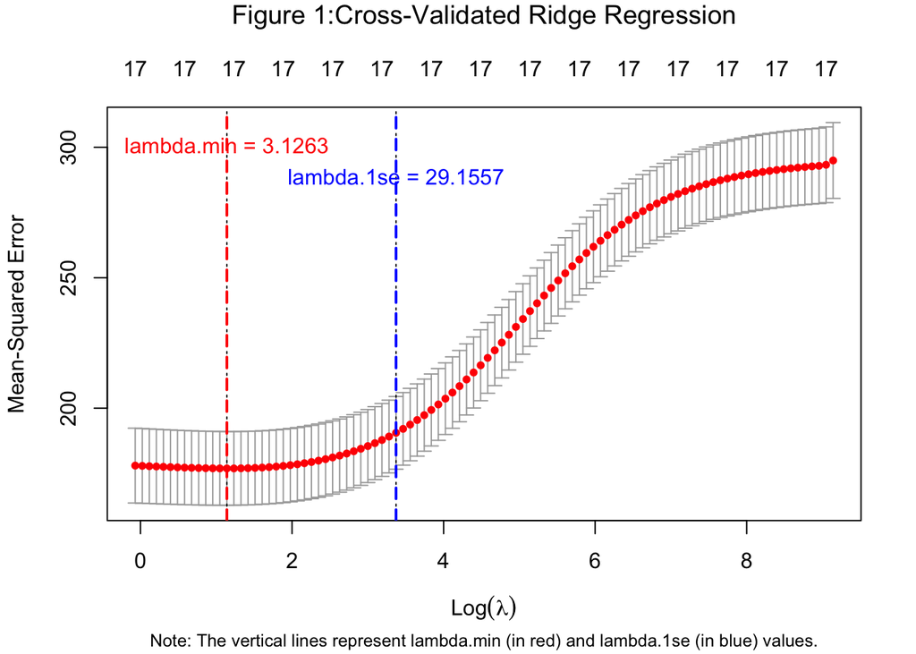

```r
# Plot the cv.glmnet object
plot(cv.ridge)

# title
mtext("Figure 1:Cross-Validated Ridge Regression", side = 3, line = 3, cex = 1.2)

# note below the plot
mtext("Note: The vertical lines represent lambda.min (in red) and lambda.1se (in blue) values.", side = 1, line = 4, cex = 0.8)


# Add vertical lines for lambda.min and lambda.1se
abline(v=log(cv.ridge$lambda.min), col="red", lwd=2, lty=2)
abline(v=log(cv.ridge$lambda.1se), col="blue", lwd=2, lty=2)


# (OpenAI, 2024)
# Define y-coordinate for annotations
y_coord <- max(cv.ridge$cvm) * 1.05

# Add text annotations for lambda.min and lambda.1se at the top
text(x=log(cv.ridge$lambda.min), y=y_coord,
     labels=paste("lambda.min =", round(cv.ridge$lambda.min, 4)),
     adj=c(0.5, 2), col="red")

text(x=log(cv.ridge$lambda.1se), y=y_coord,
     labels=paste("lambda.1se =", round(cv.ridge$lambda.1se, 4)),
     adj=c(0.5, 4), col="blue")
```

**Interpretation for Figure 1: Cross-Validated Ridge Regression**

In the above figure, each red dot represents the mean squared error for a specific value of lambda during the cross-validation process.

## 4. Fit a Ridge regression model against the training set and report on the coefficients. Is there anything interesting?

```r
# Fitting ridge regression with lambda.min
model.min <- glmnet(train_x_scaled, train_y, alpha = 0, lambda = ridge_lambda.min)
coef(model.min)
```

```
## 18 x 1 sparse Matrix of class "dgCMatrix"
##                     s0
## (Intercept) 65.4706960
## PrivateYes   2.2051031
## Apps         1.8032154
## Accept       0.6500279
## Enroll       0.3851241
## Top10perc    1.7114540
## Top25perc    2.0289134
## F.Undergrad -0.4253122
## P.Undergrad -2.1724825
## Outstate     2.6431165
## Room.Board   1.9760111
## Books       -0.2748221
## Personal    -1.2679472
## PhD          0.4527913
## Terminal     0.1611764
## S.F.Ratio    0.5653259
## perc.alumni  2.8503474
## Expend      -1.0841760
```

```r
# Fitting ridge regression with lambda.1se
model.1se <- glmnet(train_x_scaled, train_y, alpha = 0, lambda = ridge_lambda.1se)
coef(model.1se)
```

```
## 18 x 1 sparse Matrix of class "dgCMatrix"
##                      s0
## (Intercept) 65.47069597
## PrivateYes   1.18366515
## Apps         0.56670394
## Accept       0.33388268
## Enroll       0.07107754
## Top10perc    1.27336741
## Top25perc    1.32603280
## F.Undergrad -0.17605424
## P.Undergrad -1.07778222
## Outstate     1.60844867
## Room.Board   1.20786330
## Books       -0.20092396
## Personal    -0.92506656
## PhD          0.53737229
## Terminal     0.48734625
## S.F.Ratio   -0.27761689
## perc.alumni  1.55545309
## Expend       0.38274817
```

**Comparison:**

**The significant change in the expenditure coefficient between the two models is an interesting finding and may warrant further investigation to understand the underlying dynamics between spending and graduation outcomes.**

Notably, Expend has a negative coefficient (-1.084) for lambda.min, which is counter intuitive as higher spending per student is generally expected to correlate with better outcomes. Whereas Expend now has a positive coefficient (0.382), which is more aligned with expectations, suggesting that in the more regularized model, higher expenditure per student is associated with a slight increase in graduation rates.

## 5. Determine the performance of the fit model against the training set by calculating the root mean square error (RMSE).

```r
# Making predictions on the training set for lambda.min
pred_train_ridge_min <- predict(model.min, s = ridge_lambda.min , newx = train_x_scaled)

# Calculating the square root of the mean squared error
rmse_train_ridge_min <- sqrt(mean((train_y - pred_train_ridge_min)^2))


# Making predictions on the training set for lambda.1se
pred_train_ridge_1se <- predict(model.1se, s = ridge_lambda.1se , newx = train_x_scaled)

# Calculating the square root of the mean squared error for lambda.1se
rmse_train_ridge_1se <- sqrt(mean((train_y - pred_train_ridge_1se)^2))

# Create a data frame with RMSE values
ridge_rmse_values1 <- data.frame(
  Model = c('Ridge - lambda.min', 'Ridge - lambda.1se'),
  RMSE = c(rmse_train_ridge_min, rmse_train_ridge_1se)
)

# Use kable to create a nicely formatted table
kable(ridge_rmse_values1, caption = "Table 1: Training Set RMSE for Ridge Regression Models") %>%
  kable_styling(bootstrap_options = c("striped", "hover"))
```

Table 1: Training Set RMSE for Ridge Regression Models

| Model | RMSE |
| --- | --- |
| Ridge - lambda.min | 12.98732 |
| Ridge - lambda.1se | 13.67612 |

## 6. Determine the performance of the fit model against the test set by calculating the root mean square error (RMSE). Is your model overfit?

```r
# Making predictions on the test set
pred_test_ridge_min <- predict(model.min, s = ridge_lambda.min , newx = test_x_scaled)

# Calculating the square root of the mean squared error for lambda.min
rmse_test_ridge_min <- sqrt(mean((test_y - pred_test_ridge_min)^2))


# Making predictions on the test set for lambda.1se
pred_test_ridge_1se <- predict(model.1se, s = ridge_lambda.1se , newx = test_x_scaled)

# Calculating the square root of the mean squared error for lambda.1se
rmse_test_ridge_1se <- sqrt(mean((test_y - pred_test_ridge_1se)^2))

# Create a data frame with RMSE values
ridge_rmse_values2 <- data.frame(
  Model = c('Ridge - lambda.min', 'Ridge - lambda.1se'),
  RMSE = c(rmse_test_ridge_min, rmse_test_ridge_1se)
)

# Use kable to create a nicely formatted table
kable(ridge_rmse_values2, caption = "Table 2: Test Set RMSE for Ridge Regression Models") %>%
  kable_styling(bootstrap_options = c("striped", "hover"))
```

Table 2: Test Set RMSE for Ridge Regression Models

| Model | RMSE |
| --- | --- |
| Ridge - lambda.min | 12.09748 |
| Ridge - lambda.1se | 12.89809 |

**Interpretation for Table 2:**

**Based on the RMSE values for both training and test sets, neither model appears to be overfitting significantly.** The Ridge regression model with lambda.min is performing better on the test set, as indicated by its lower RMSE value of 12.09748 compared to the RMSE of 12.89809 for the model with lambda.1se.

# Lasso

## 7. Use the cv.glmnet function to estimate the *lambda.min* and *lambda.1se* values. Compare and discuss the values.

```r
# Performing cross validation
set.seed(123)
cv.lasso <- cv.glmnet(train_x_scaled, train_y, alpha = 1, nfolds = 10)
# (Code Sorced from Canvas- Lab: Regularization)

# Finding lambda.min
lasso_lambda.min <- cv.lasso$lambda.min


lasso_lambda.1se <- cv.lasso$lambda.1se


cat("(Lasso Regression) Lambda min:", lasso_lambda.min, "\n")
```

```
## (Lasso Regression) Lambda min: 0.1707654
```

```r
cat("(Lasso Regression) Lambda 1se:", lasso_lambda.1se, "\n")
```

```
## (Lasso Regression) Lambda 1se: 1.747837
```

**Interpretation of Lambda Values:**

- **Lambda.min (0.1707654):** This value of the regularization parameter is where the cross-validated mean squared error (MSE) is at its lowest. This model is potentially better predictive performance on the training data.
- **Lambda 1se** **(1.747837)**: This value is larger than lambda.min, meaning it imposes more regularization. This leads to a simpler model with fewer non-zero coefficients due to greater shrinkage.

**Comparison:**

The choice between these two values represents a trade-off between model complexity and generalization. lambda.min aims for the lowest possible error on the training set, potentially at the cost of complexity, while lambda.1se aims for a balance that might generalize better to new data, potentially at the cost of slightly increased error. (Goyal, 2017) The model using lambda.1se is typically more interpretable due to its simplicity, as it includes only the most significant predictors.

In summary, lambda.min provides the best fit to the training data, while lambda.1se offers a more conservative fit that might perform better when predicting new, unseen data.

## 8. Plot the results from the *cv.glmnet* function and provide an interpretation. What does this plot tell us?

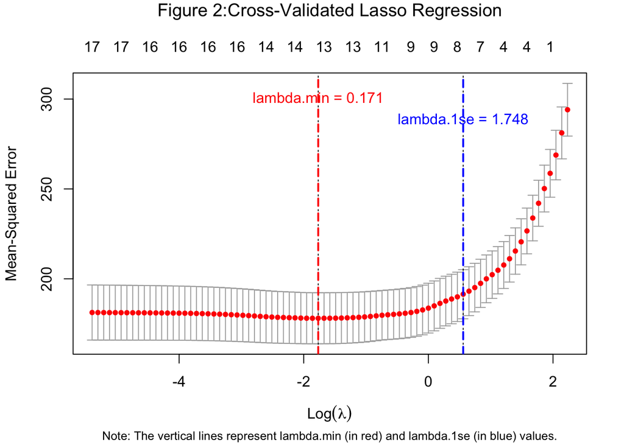

```r
# Plotting the graph
plot(cv.lasso)

# title
mtext("Figure 2:Cross-Validated Lasso Regression", side = 3, line = 3, cex = 1.2)

# note below the plot
mtext("Note: The vertical lines represent lambda.min (in red) and lambda.1se (in blue) values.", side = 1, line = 4, cex = 0.8)

# Add vertical lines for lambda.min and lambda.1se
abline(v=log(cv.lasso$lambda.min), col="red", lwd=2, lty=2)
abline(v=log(cv.lasso$lambda.1se), col="blue", lwd=2, lty=2)
# (OpenAI, 2024)


# Add text annotations for lambda.min and lambda.1se at the top
text(x=log(cv.lasso$lambda.min), y=y_coord,
     labels=paste("lambda.min =", round(cv.lasso$lambda.min, 3)),
     adj=c(0.5, 2), col="red")

text(x=log(cv.lasso$lambda.1se), y=y_coord,
     labels=paste("lambda.1se =", round(cv.lasso$lambda.1se, 3)),
     adj=c(0.5, 4), col="blue")
```

**Interpretation for Figure 2: Cross-Validated Lasso Regression**

- The graph shows that as regularization increases, the model complexity decreases and the MSE generally increases after hitting the minimum at lambda.min.
- lambda.min corresponds to the minimum MSE. It suggests the model that provides the best fit to the data.
- lambda.1se is where the MSE is within one standard error of the minimum MSE. It suggests a simpler model that potentially trades off a slight increase in MSE for increased model simplicity and potentially better generalizability.
- Numbers at the Top represent the count of non-zero coefficients in the Lasso model at each lambda value. As it increases, the number of non-zero coefficients decreases, indicating that more predictors are being shrunk towards zero, which simplifies the model.

## 9. Fit a LASSO regression model against the training set and report on the coefficients. Do any coefficients reduce to zero? If so, which ones?

```r
# Fitting Lasso regression with lambda.min
model.min <- glmnet(train_x_scaled, train_y, alpha = 1, lambda = lasso_lambda.min)
coef(model.min)
```

```
## 18 x 1 sparse Matrix of class "dgCMatrix"
##                     s0
## (Intercept) 65.4706960
## PrivateYes   2.2968637
## Apps         2.9931741
## Accept       .
## Enroll       .
## Top10perc    1.3299774
## Top25perc    2.3129547
## F.Undergrad  .
## P.Undergrad -2.4271782
## Outstate     3.1498799
## Room.Board   1.9947667
## Books       -0.1089365
## Personal    -1.1823389
## PhD          0.2887319
## Terminal     .
## S.F.Ratio    0.5972018
## perc.alumni  3.2856708
## Expend      -1.6559343
```

```r
# Fitting Lasso regression with lambda.1se
model.1se <- glmnet(train_x_scaled, train_y, alpha = 1, lambda = lasso_lambda.1se)
coef(model.1se)
```

```
## 18 x 1 sparse Matrix of class "dgCMatrix"
##                     s0
## (Intercept) 65.4706960
## PrivateYes   .
## Apps         .
## Accept       .
## Enroll       .
## Top10perc    0.8529503
## Top25perc    2.0799340
## F.Undergrad  .
## P.Undergrad -0.7369424
## Outstate     3.9444471
## Room.Board   1.0182058
## Books        .
## Personal    -0.3376527
## PhD          .
## Terminal     .
## S.F.Ratio    .
## perc.alumni  2.2711307
## Expend       .
```

## 10. Determine the performance of the fit model against the training set by calculating the root mean square error (RMSE).

```r
# Making predictions on the training set
pred_train_lasso_min <- predict(model.min, s = lasso_lambda.min , newx = train_x_scaled)

# Calculating the square root of the mean squared error for lambda.min
rmse_train_lasso_min <- sqrt(mean((train_y - pred_train_lasso_min)^2))

# Making predictions on the training set for lambda.1se
pred_train_lasso_1se <- predict(model.1se, s = lasso_lambda.1se , newx = train_x_scaled)

# Calculating the square root of the mean squared error for lambda.1se
rmse_train_lasso_1se <- sqrt(mean((train_y - pred_train_lasso_1se)^2))

# Create a data frame with RMSE values
lasso_rmse_values1 <- data.frame(
  Model = c('Lasso - lambda.min', 'Lasso - lambda.1se'),
  RMSE = c(rmse_train_lasso_min, rmse_train_lasso_1se)
)

# Use kable to create a nicely formatted table
kable(lasso_rmse_values1, caption = "Table 3: Training Set RMSE for Lasso Regression Models") %>%
  kable_styling(bootstrap_options = c("striped", "hover"))
```

Table 3: Training Set RMSE for Lasso Regression Models

| Model | RMSE |
| --- | --- |
| Lasso - lambda.min | 12.93813 |
| Lasso - lambda.1se | 13.59122 |

## 11. Determine the performance of the fit model against the test set by calculating the root mean square error (RMSE). Is your model overfit?

```r
# Making predictions on the test set
pred_test_lasso_min <- predict(model.min, s = lasso_lambda.min , newx = test_x_scaled)

# Calculating the square root of the mean squared error for lambda.min
rmse_test_lasso_min <- sqrt(mean((test_y - pred_test_lasso_min)^2))


# Making predictions on the test set for lambda.1se
pred_test_lasso_1se <- predict(model.1se, s = lasso_lambda.1se , newx = test_x_scaled)

# Calculating the square root of the mean squared error for lambda.1se
rmse_test_lasso_1se <- sqrt(mean((test_y - pred_test_lasso_1se)^2))

# Create a data frame with RMSE values
lasso_rmse_values2 <- data.frame(
  Model = c('Lasso - lambda.min', 'Lasso - lambda.1se'),
  RMSE = c(rmse_test_lasso_min, rmse_test_lasso_1se)
)

# Use kable to create a nicely formatted table
kable(lasso_rmse_values2, caption = "Table 4: Test Set RMSE for Lasso Regression Models") %>%
  kable_styling(bootstrap_options = c("striped", "hover"))
```

Table 4: Test Set RMSE for Lasso Regression Models

| Model | RMSE |
| --- | --- |
| Lasso - lambda.min | 12.04458 |
| Lasso - lambda.1se | 12.66914 |

**Interpretation for Table 4:**

The RMSE values are relatively close to each other, with the lambda.min model performing slightly better on the test set than the lambda.1se model.

The fact that the lambda.1se model, which is more regularized and thus less prone to overfitting, has an RMSE that is not substantially higher than the lambda.min model suggests good generalizability. The difference in RMSE between the two models is relatively small (approximately 0.62456), which further implies that the lambda.min model is not overfitting by much, if at all.

**Given that both Lasso models have lower RMSEs on the test set compared to the training set, there is no evidence of overfitting. Instead, the models seem to be well-tuned to generalize to new data.**

## 12. Which model performed better and why? Is that what you expected?

```r
# Create a data frame with all RMSE values
comparison <- data.frame(
  Model = c('Lasso - lambda.min', 'Lasso - lambda.1se',
            'Ridge - lambda.min', 'Ridge - lambda.1se'),
  Train_Dataset = c(rmse_train_lasso_min, rmse_train_lasso_1se,
                    rmse_train_ridge_min, rmse_train_ridge_1se),
  Test_Dataset = c(rmse_test_lasso_min, rmse_test_lasso_1se,
                   rmse_test_ridge_min, rmse_test_ridge_1se)
)

comparison$Difference <- comparison$Train_Dataset - comparison$Test_Dataset

  # Use kable to create a nicely formatted table
kable(comparison, caption = "Table 5: RMSE for Lasso and Ridge Regression Models") %>%
  kable_styling(bootstrap_options = c("striped", "hover"))
```

Table 5: RMSE for Lasso and Ridge Regression Models

| Model | Train_Dataset | Test_Dataset | Difference |
| --- | --- | --- | --- |
| Lasso - lambda.min | 12.93813 | 12.04458 | 0.8935487 |
| Lasso - lambda.1se | 13.59122 | 12.66914 | 0.9220737 |
| Ridge - lambda.min | 12.98732 | 12.09748 | 0.8898410 |
| Ridge - lambda.1se | 13.67612 | 12.89809 | 0.7780256 |

**Interpretation for Table 5:**

- **Lasso - lambda.min**: This model has the lowest RMSE on the test dataset (12.04458), indicating the best predictive accuracy among the models listed when applied to unseen data.
- **Lasso - lambda.1se**: The RMSE on the test dataset (12.66914) is higher than that of Lasso - lambda.min, suggesting less predictive accuracy.
- **Ridge - lambda.min**: It has a slightly higher RMSE on the test dataset (12.09748) compared to Lasso - lambda.min, but the difference is marginal.
- **Ridge - lambda.1se**: This model has the smallest difference between training and test RMSE, suggesting it generalizes slightly better than the others. However, since its test RMSE is higher compared to the Lasso - lambda.min, the better generalization does not translate into better predictive performance on the test set.

For both Lasso and Ridge regression, the models with lambda.min have test RMSEs that are very close to their training RMSEs, which suggests that both models are well-tuned to the specific characteristics of the dataset.

**Best Performing Model:**

**The Lasso - lambda.min model performed the best in terms of predictive accuracy on the test set.** The differences in RMSE are not large, which suggests that all models are performing relatively well and that there is no significant overfitting occurring with the less regularized models.

## 13. Refer to the ALY6015_Feature_Selection_R.pdf document for how to perform stepwise selection and then fit a model. Did this model perform better or as well as Ridge regression or LASSO? Which method do you prefer and why?

```r
# Fit a full model with all predictors for the stepwise selection
all_predictors <- lm(Grad.Rate ~ ., data = train)

# Perform stepwise selection using both directions (forward and backward)
step_selection <- step(all_predictors, direction = "both", trace = 0)

#(OpenAI,2024)

# Summary of the stepwise model
summary(step_selection)
```

```
##
## Call:
## lm(formula = Grad.Rate ~ Private + Apps + Top25perc + P.Undergrad +
##     Outstate + Room.Board + Personal + perc.alumni + Expend,
##     data = train)
##
## Residuals:
##     Min      1Q  Median      3Q     Max
## -51.958  -7.430  -0.454   6.877  51.155
##
## Coefficients:
##               Estimate Std. Error t value Pr(>|t|)
## (Intercept) 33.4595503  3.1611031  10.585  < 2e-16 ***
## PrivateYes   5.2645566  1.9033280   2.766  0.00587 **
## Apps         0.0010436  0.0002266   4.605 5.17e-06 ***
## Top25perc    0.1755962  0.0378963   4.634 4.52e-06 ***
## P.Undergrad -0.0016522  0.0004142  -3.988 7.57e-05 ***
## Outstate     0.0008413  0.0002711   3.104  0.00201 **
## Room.Board   0.0019041  0.0006840   2.784  0.00556 **
## Personal    -0.0018738  0.0009133  -2.052  0.04070 *
## perc.alumni  0.2832253  0.0589896   4.801 2.05e-06 ***
## Expend      -0.0004470  0.0001586  -2.819  0.00500 **
## ---
## Signif. codes:  0 '***' 0.001 '**' 0.01 '*' 0.05 '.' 0.1 ' ' 1
##
## Residual standard error: 13.08 on 536 degrees of freedom
## Multiple R-squared:  0.4287, Adjusted R-squared:  0.4191
## F-statistic: 44.68 on 9 and 536 DF,  p-value: < 2.2e-16
```

```r
# Make predictions on the test set
pred_step_select <- predict(step_selection, newdata = test)

# Calculate RMSE for stepwise model
rmse_stepwise <- sqrt(mean((pred_step_select - test$Grad.Rate) ^ 2))
rmse_stepwise
```

```
## [1] 12.00483
```

```r
# Compare test RMSE values
rmse_comparison <- data.frame(
  Model = c("Ridge", "LASSO", "Stepwise"),
  RMSE = c( rmse_test_ridge_min, rmse_test_lasso_min, rmse_stepwise)
)

  # Use kable to create a nicely formatted table
kable(rmse_comparison, caption = "Table 6: RMSE Comparison for all three models") %>%
  kable_styling(bootstrap_options = c("striped", "hover"))
```

Table 6: RMSE Comparison for all three models

| Model | RMSE |
| --- | --- |
| Ridge | 12.09748 |
| LASSO | 12.04458 |
| Stepwise | 12.00483 |

**Interpretation for Table 6:**

The Stepwise selection model has the lowest RMSE of the three, indicating it performed slightly better in terms of predictive accuracy on the dataset.

**Model Performance-**

- Stepwise Regression provided the best predictive accuracy with the lowest RMSE.
- LASSO performed slightly worse than Stepwise but better than Ridge.
- Ridge Regression had the highest RMSE, suggesting it was the least accurate among the three for this particular dataset.

**Method Preference**-

Although Stepwise Regression is effective in this context, I would still prefer **LASSO (Least Absolute Shrinkage and Selection Operator)**. As it can be preferred when dealing with datasets that have a large number of predictors because it performs both variable selection and regularization. It tends to produce simpler, more interpretable models, especially useful when the goal is not just prediction but also understanding the influence of different variables.

## Conclusion

Upon careful analysis and comparison of Ridge and Lasso regression models alongside a Stepwise selection model, it is evident that each method has its merits based on the RMSE scores for both training and test datasets. The Lasso model with lambda.min demonstrated superior predictive accuracy on the test set, highlighting its capability for feature selection and model simplicity. However, the Stepwise model marginally outperformed both Ridge and Lasso in terms of test RMSE, suggesting it was slightly more accurate in predicting the graduation rate for this particular dataset. Despite the effectiveness of Stepwise regression in this context, Lasso remains a preferred method due to its robustness in handling numerous predictors and its inherent feature selection property, which is crucial for interpretability and model simplicity.

## References

- *OpenAI. (2021). ChatGPT (Version 3.5). OpenAI.https://chat.openai.com/*
- Frasca. (n.d.). Lab: Regularization Video [Video]. Panopto. Northeastern University
- Goyal. (2017). In layman’s terms, what is lambda for lasso and ridge regression? quora.com. Retrieved February 4, 2024, from https://www.quora.com/In-laymans-terms-what-is-lambda-for-lasso-and-ridge-regression
- Northeastern University. (n.d.). ALY6015 Feature Selection R [PDF file]